# Week_2_RClub_2020

Shannon Cheng

5/7/2020

# 3.2.4 Exercises

### 1. Run `ggplot(data = mpg)`. What do you see?

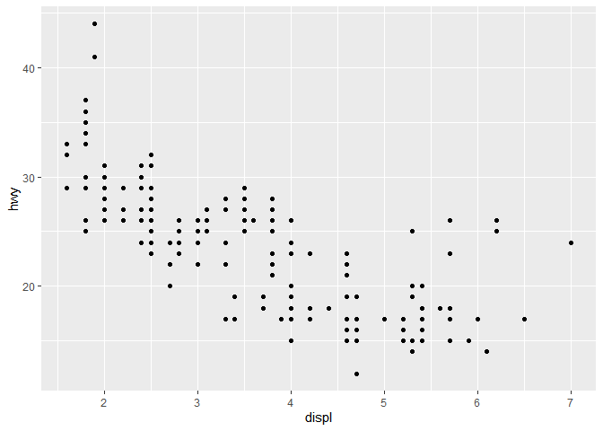

```r
ggplot(data = mpg) +
   geom_point(mapping = aes(x = displ, y = hwy))
```

### 3. What does the `drv` variable describe? Read the `?mpg` to find out.

##### The `drv` variable describes the type of drive train, where f = front-wheel drive, r = rear wheel drive, 4 = 4wd

### 4. Make a scatterplot of `hwy` vs `cyl`.

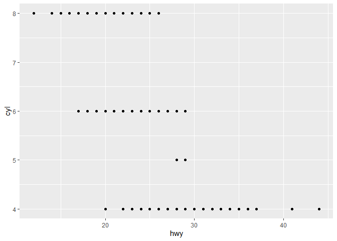

```r
ggplot(data = mpg) +
   geom_point(mapping = aes(x = hwy, y = cyl))
```

### 5. What happens if you make a scatterplot of `class` vs `drv`? Why is the plot not useful?

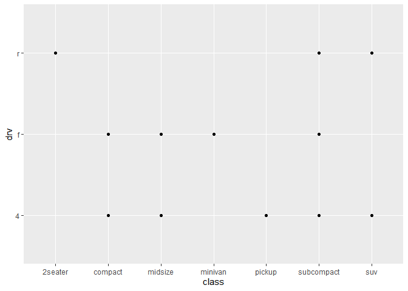

```r
ggplot(data = mpg) +
   geom_point(mapping = aes(x = class, y = drv))
```

# 3.3.1 Exercises

### 1. What’s gone wrong with this code? Why are the points not blue?

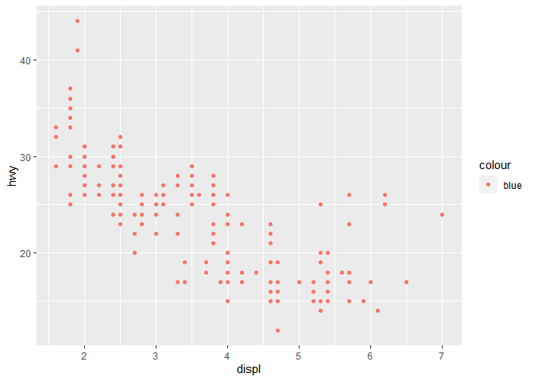

```r
ggplot(data = mpg) +
  geom_point(mapping = aes(x = displ, y = hwy, color = "blue"))
```

##### The points are not blue because the parenthesis is coded after “blue” and not after y = hwy.

### 2. Which variables in `mpg` are categorical? Which variables are continuous? (Hint: type `?mpg` to read the documentation for the dataset). How can you see this information when you run `mpg`?

##### Categorical: manufacturer, model, year, trans, drv, fl, class

##### Continuous: displ, cyl, cty, hwy

### 3. Map a continuous variable to `color`, `size`, and `shape`. How do these aesthetics behave differently for categorical vs. continuous variables?

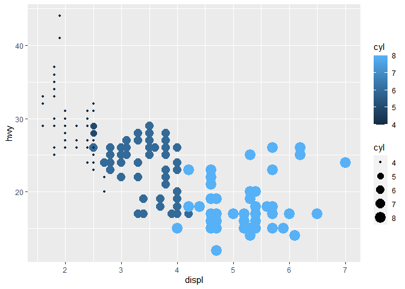

```r
ggplot(data = mpg) +
  geom_point(mapping = aes(x = displ, y = hwy, color = cyl, size = cyl))
```

##### A continuous variable cannot be mapped to shape.

### 4. What happens if you map the same variable to multiple aesthetics?

##### As seen above, the variable will show multiple aesthetics.

### 5. What does the `stroke` aesthetic do? What shapes does it work with? (Hint: use `?geom_point`)

##### The `stroke` aesthetic modifies the width of the border.

### 6. What happens if you map an aesthetic to something other than a variable name, like `aes(colour = displ < 5)`? Note, you’ll also need to specify x and y.

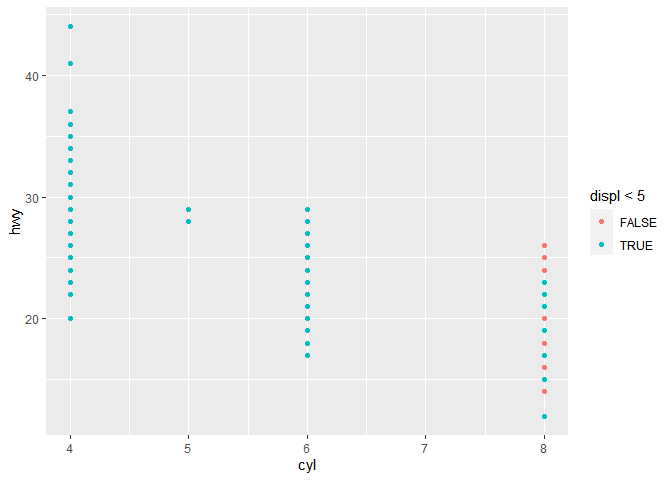

```r
ggplot(data = mpg) +
  geom_point(mapping = aes(x = cyl, y = hwy, color = displ < 5))
```

##### If a point has displ < 5, it will show as one color; if a point has displ > 5, it will show as another color.

# 3.5.1 Exercises

### 1. What happens if you facet on a continuous variable?

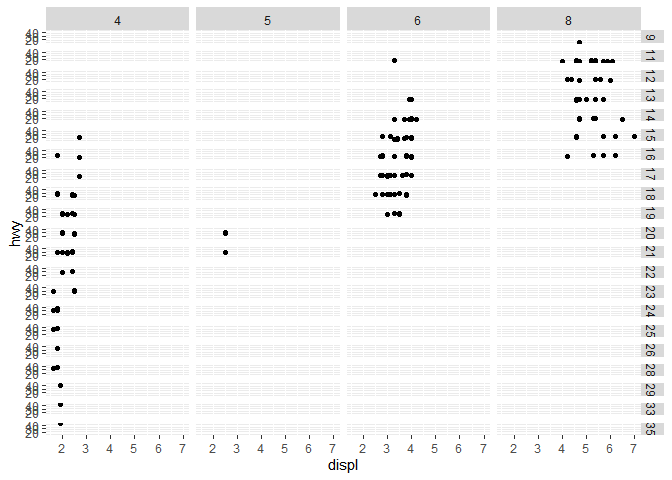

```r
ggplot(data = mpg) +
  geom_point(mapping = aes(x = displ, y = hwy)) +
  facet_grid(cty ~ cyl)
```

##### The facet grids become unreadable.

### 2. What do the empty cells in plot with `facet_grid(drv ~ cyl)` mean? How do they relate to this plot?

```
ggplot(data = mpg) +
  geom_point(mapping = aes(x = drv, y = cyl))
```

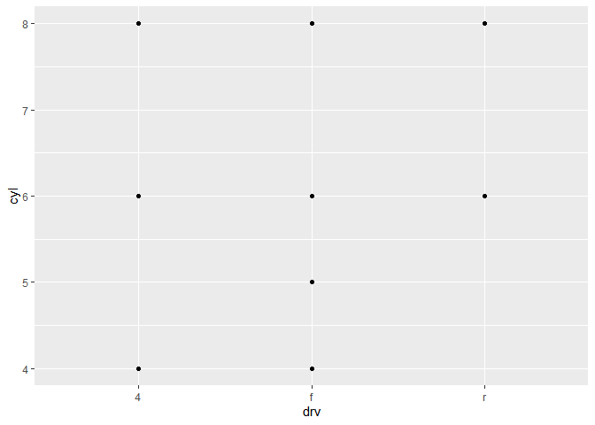

```r
ggplot(data = mpg) +
  geom_point(mapping = aes(x = drv, y = cyl))
```

```r
  facet_grid(drv ~ cyl)
```

[output not shown]

##### The plot is facetting cyl and drv into cyl and drv, which is why the points are on cross points of the plot instead of in the cells.

### 3. What plots does the following code make? What does `.` do?

```
ggplot(data = mpg) +
  geom_point(mapping = aes(x = displ, y = hwy)) +
  facet_grid(drv ~ .)

ggplot(data = mpg) +
  geom_point(mapping = aes(x = displ, y = hwy)) +
  facet_grid(. ~ cyl)
```

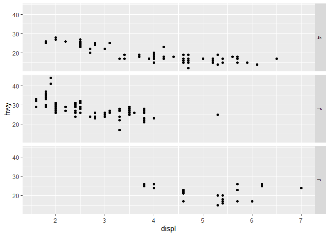

```r
ggplot(data = mpg) +
  geom_point(mapping = aes(x = displ, y = hwy)) +
  facet_grid(drv ~ .)
```

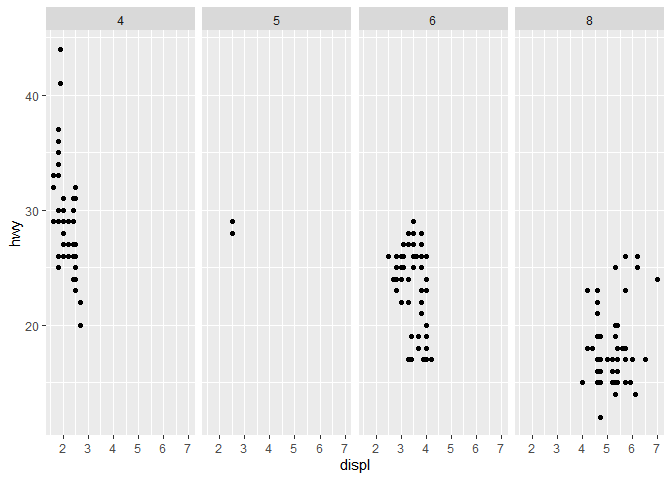

```r
ggplot(data = mpg) +
  geom_point(mapping = aes(x = displ, y = hwy)) +
  facet_grid(. ~ cyl)
```

##### The `.` makes it so that the data is only categorized by one value.

### 4. Take the first faceted plot in this section:

```
ggplot(data = mpg) +
  geom_point(mapping = aes(x = displ, y = hwy)) +
  facet_wrap(~ class, nrow = 2)
```

### What are the advantages to using faceting instead of the colour aesthetic? What are the disadvantages? How might the balance change if you had a larger dataset?

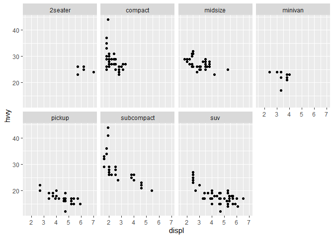

```r
ggplot(data = mpg) +
  geom_point(mapping = aes(x = displ, y = hwy)) +
  facet_wrap(~ class, nrow = 2)
```

##### Using the color aesthetic would allow us to compare the data to all data. However, when we have a larger dataset, it would be easier to use facets as the color aesthetic would become too hectic.

### 5. Read `?facet_wrap`. What does `nrow` do? What does `ncol` do? What other options control the layout of the individual panels? Why doesn’t `facet_grid()` have `nrow` and `ncol` arguments?

##### `nrow` is the number of rows, and `ncol` is the number of columns. Other options to control the layout of individual panels are “facets”, “scales”, “shrink”, “labeller”, “as.table”, “switch”, “drop”, “dir”, and “strip.position”.

##### `facet_grid()` does not have `nrow` and `ncol` arguments because facets are like cells, and cells do not have rows and columns.

### 6. When using `facet_grid()` you should usually put the variable with more unique levels in the columns. Why?

##### Otherwise, the data in the facets would be too crowded to see.

# 3.6.1 Exercises

### 1. What geom would you use to draw a line chart? A boxplot? A histogram? An area chart?

### 2. Run this code in your head and predict what the output will look like. Then, run the code in R and check your predictions.

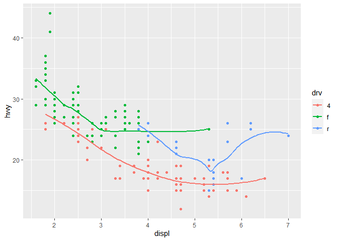

```r
ggplot(data = mpg, mapping = aes(x = displ, y = hwy, color = drv)) +
  geom_point() +
  geom_smooth(se = FALSE)
```

### 3. What does `show.legend = FALSE` do? What happens if you remove it? Why do you think I used it earlier in the chapter?

##### It does not show the legend.

### 4. What does the `se` argument to `geom_smooth()` do?

##### It removes the confidence intervals.

### 5. Will these two graphs look different? Why/why not?

```
ggplot(data = mpg, mapping = aes(x = displ, y = hwy)) +
  geom_point() +
  geom_smooth()

ggplot() +
  geom_point(data = mpg, mapping = aes(x = displ, y = hwy)) +
  geom_smooth(data = mpg, mapping = aes(x = displ, y = hwy))
```

##### They will not look different.

### 6.

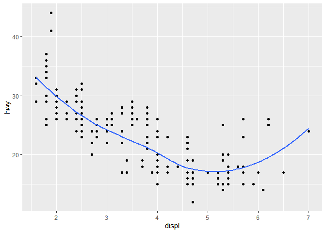

```r
ggplot(data = mpg) +
  geom_point(mapping = aes(x = displ, y = hwy)) +
  geom_smooth(mapping = aes(x = displ, y = hwy), se = FALSE)
```